# Antibióticos en sistemas acuáticos: análisis exploratorio

- Mostrar todo el código
- Ocultar todo el código
- Ver el código fuente

Informe reproducible con datos simulados

Autor/a

Cristóbal Gaete Gamboa

## Datos y preparación

**Código**

```r
library(readxl)
library(dplyr)
library(tidyr)
library(ggplot2)
library(broom)
library(knitr)
library(plotly)


# 1. IMPORTAR LOS DATOS
ruta <- "Dataset_Trabajo_VDA.xlsx"

if (!file.exists(ruta)) {
  stop("No se encuentra el archivo Excel")
}

datos <- read_excel(ruta)

# 2. DEFINIR LOS ANTIBIÓTICOS
antibioticos <- c(
  "AMX_ng_L", "AZM_ng_L", "CIP_ng_L",
  "SMX_ng_L", "CFX_ng_L", "CLR_ng_L",
  "AMP_ng_L", "LEV_ng_L", "MTZ_ng_L",
  "OTC_ng_L"
)

# 3. VERIFICAR LAS COLUMNAS
variables <- c(
  "Nombre_Sitio",
  "Temperatura_Agua_C",
  "Caudal_m3_s",
  "Precipitacion_Diaria_mm",
  antibioticos
)

faltantes <- setdiff(variables, names(datos))

if (length(faltantes) > 0) {
  stop(
    "Faltan columnas: ",
    paste(faltantes, collapse = ", ")
  )
}

# 4. TRANSFORMAR LOS DATOS
largo <- datos |>
  pivot_longer(
    cols = all_of(antibioticos),
    names_to = "Antibiotico",
    values_to = "Concentracion"
  ) |>
  mutate(
    Antibiotico = sub("_ng_L$", "", Antibiotico),
    Concentracion = as.numeric(Concentracion)
  )

# 5. GENERAR ESTADÍSTICAS DESCRIPTIVAS
resumen <- largo |>
  group_by(Nombre_Sitio, Antibiotico) |>
  summarise(
    n = sum(!is.na(Concentracion)),
    mediana_ng_L = median(
      Concentracion,
      na.rm = TRUE
    ),
    .groups = "drop"
  )

# 6. PRESENTAR LA TABLA
kable(
  head(resumen, 15),
  digits = 2,
  caption = "Resumen descriptivo por sitio y antibiótico"
)
```

Resumen descriptivo por sitio y antibiótico

| Nombre_Sitio | Antibiotico | n | mediana_ng_L |
| --- | --- | --- | --- |
| El Trebal - Efluente | AMP | 10 | 334.0 |
| El Trebal - Efluente | AMX | 10 | 612.5 |
| El Trebal - Efluente | AZM | 10 | 405.0 |
| El Trebal - Efluente | CFX | 10 | 512.5 |
| El Trebal - Efluente | CIP | 10 | 277.5 |
| El Trebal - Efluente | CLR | 10 | 187.5 |
| El Trebal - Efluente | LEV | 10 | 173.0 |
| El Trebal - Efluente | MTZ | 10 | 256.0 |
| El Trebal - Efluente | OTC | 10 | 81.5 |
| El Trebal - Efluente | SMX | 10 | 730.0 |
| La Farfana - Afluente | AMP | 10 | 2160.0 |
| La Farfana - Afluente | AMX | 10 | 3785.0 |
| La Farfana - Afluente | AZM | 10 | 2115.0 |
| La Farfana - Afluente | CFX | 10 | 2885.0 |
| La Farfana - Afluente | CIP | 10 | 1660.0 |

## Hallazgo 1. Distribución entre sitios

El gráfico permite comparar la distribución de concentraciones entre puntos de muestreo. La presencia de valores extremos y la variabilidad deben interpretarse según el diseño de simulación. En esto se puede apreciar que las mayores concentraciones para los antibioticos ocurren en el afluente de la planta de tratamiento residual, esto debido a que en este sector es donde se recibe todo el residudo de consumo humano.

**Código**

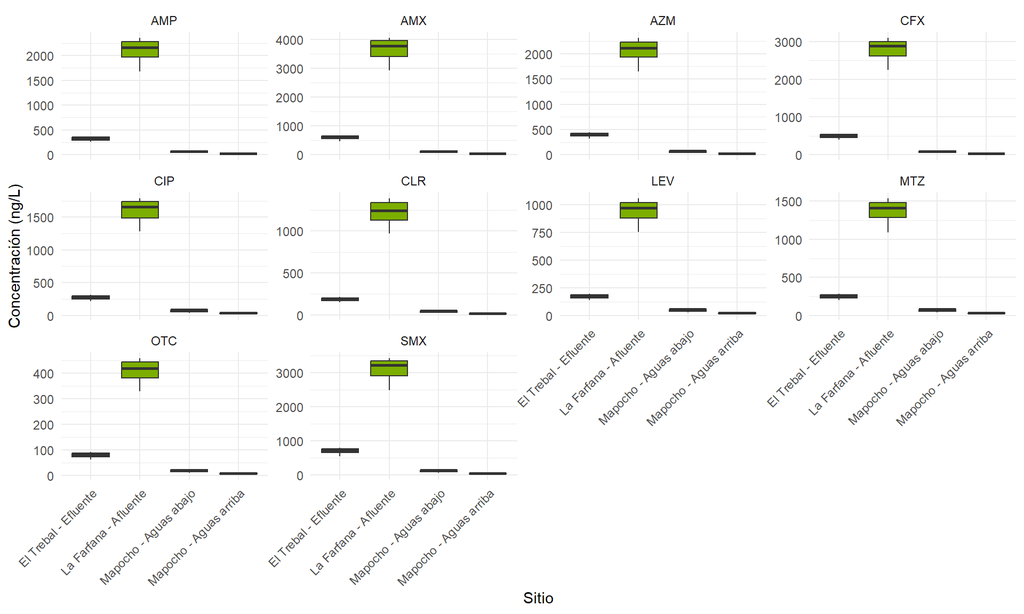

Figura 1: Concentraciones simuladas de antibióticos por sitio de muestreo.

```r
ggplot(largo, aes(x = Nombre_Sitio, y = Concentracion, fill = Nombre_Sitio)) +
  geom_boxplot(outlier.alpha = 0.4, na.rm = TRUE) +
  facet_wrap(~ Antibiotico, scales = "free_y") +
  labs(x = "Sitio", y = "Concentración (ng/L)") +
  theme_minimal() + theme(axis.text.x = element_text(angle = 45, hjust = 1), legend.position = "none")
```

## Hallazgo 2. Relación con temperatura

**Código**

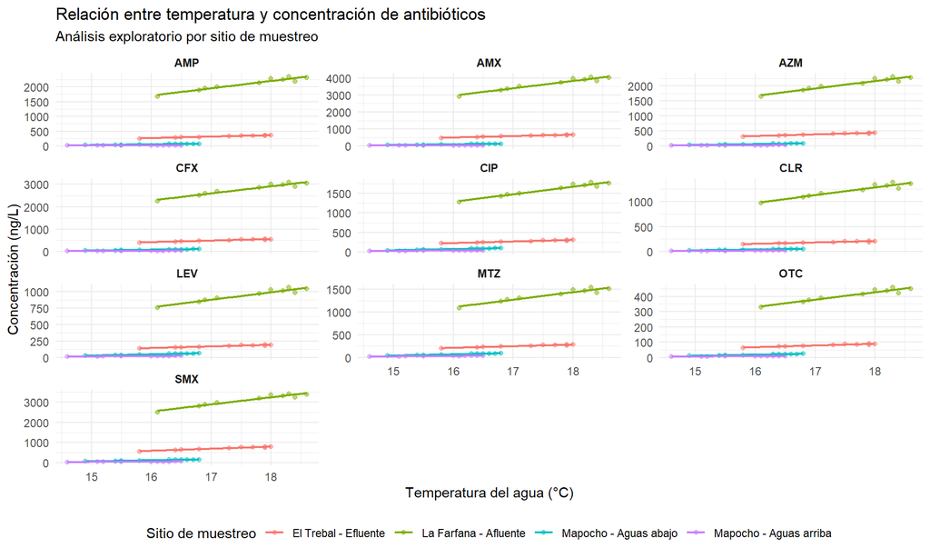

Figura 2: Temperatura del agua y concentración simulada por antibiótico.

```r
ggplot(
  largo,
  aes(
    x = Temperatura_Agua_C,
    y = Concentracion,
    color = Nombre_Sitio
  )
) +
  geom_point(
    alpha = 0.5,
    size = 1.5,
    na.rm = TRUE
  ) +
  geom_smooth(
    method = "lm",
    se = FALSE,
    linewidth = 0.8,
    na.rm = TRUE
  ) +
  facet_wrap(
    ~ Antibiotico,
    scales = "free_y",
    ncol = 3
  ) +
  labs(
    title = "Relación entre temperatura y concentración de antibióticos",
    subtitle = "Análisis exploratorio por sitio de muestreo",
    x = "Temperatura del agua (°C)",
    y = "Concentración (ng/L)",
    color = "Sitio de muestreo"
  ) +
  theme_minimal() +
  theme(
    legend.position = "bottom",
    strip.text = element_text(face = "bold")
  )
```

## Hallazgo 3. Caudal, precipitación y modelo exploratorio

Se ajusta un modelo lineal por sitio y antibiótico para explorar asociaciones conjuntas. Se informa R², que mide el ajuste dentro de la muestra y no demuestra capacidad predictiva externa.

**Código**

```r
modelos <- largo |>
  group_by(Nombre_Sitio, Antibiotico) |>
  nest() |>
  mutate(
    modelo = lapply(data, function(d) {
      d <- d |> select(Concentracion, Temperatura_Agua_C, Caudal_m3_s, Precipitacion_Diaria_mm) |> na.omit()
      if (nrow(d) < 6 || any(vapply(d[-1], function(x) length(unique(x)) < 2, logical(1)))) return(NULL)
      tryCatch(lm(Concentracion ~ Temperatura_Agua_C + Caudal_m3_s + Precipitacion_Diaria_mm, data = d), error = function(e) NULL)
    }),
    r2 = vapply(modelo, function(m) if (is.null(m)) NA_real_ else glance(m)$r.squared, numeric(1))
  )
kable(modelos |> select(Nombre_Sitio, Antibiotico, r2), digits = 3, caption = "R² por sitio y antibiótico")
```

R² por sitio y antibiótico

| Nombre_Sitio | Antibiotico | r2 |
| --- | --- | --- |
| La Farfana - Afluente | AMX | 0.974 |
| La Farfana - Afluente | AZM | 0.976 |
| La Farfana - Afluente | CIP | 0.981 |
| La Farfana - Afluente | SMX | 0.976 |
| La Farfana - Afluente | CFX | 0.977 |
| La Farfana - Afluente | CLR | 0.966 |
| La Farfana - Afluente | AMP | 0.974 |
| La Farfana - Afluente | LEV | 0.980 |
| La Farfana - Afluente | MTZ | 0.978 |
| La Farfana - Afluente | OTC | 0.971 |
| El Trebal - Efluente | AMX | 0.980 |
| El Trebal - Efluente | AZM | 0.980 |
| El Trebal - Efluente | CIP | 0.978 |
| El Trebal - Efluente | SMX | 0.978 |
| El Trebal - Efluente | CFX | 0.980 |
| El Trebal - Efluente | CLR | 0.968 |
| El Trebal - Efluente | AMP | 0.980 |
| El Trebal - Efluente | LEV | 0.978 |
| El Trebal - Efluente | MTZ | 0.974 |
| El Trebal - Efluente | OTC | 0.971 |
| Mapocho - Aguas arriba | AMX | 0.981 |
| Mapocho - Aguas arriba | AZM | 0.982 |
| Mapocho - Aguas arriba | CIP | 0.986 |
| Mapocho - Aguas arriba | SMX | 0.976 |
| Mapocho - Aguas arriba | CFX | 0.983 |
| Mapocho - Aguas arriba | CLR | 0.964 |
| Mapocho - Aguas arriba | AMP | 0.974 |
| Mapocho - Aguas arriba | LEV | 0.969 |
| Mapocho - Aguas arriba | MTZ | 0.986 |
| Mapocho - Aguas arriba | OTC | 0.935 |
| Mapocho - Aguas abajo | AMX | 0.977 |
| Mapocho - Aguas abajo | AZM | 0.976 |
| Mapocho - Aguas abajo | CIP | 0.977 |
| Mapocho - Aguas abajo | SMX | 0.976 |
| Mapocho - Aguas abajo | CFX | 0.975 |
| Mapocho - Aguas abajo | CLR | 0.977 |
| Mapocho - Aguas abajo | AMP | 0.976 |
| Mapocho - Aguas abajo | LEV | 0.975 |
| Mapocho - Aguas abajo | MTZ | 0.978 |
| Mapocho - Aguas abajo | OTC | 0.972 |

**Código**

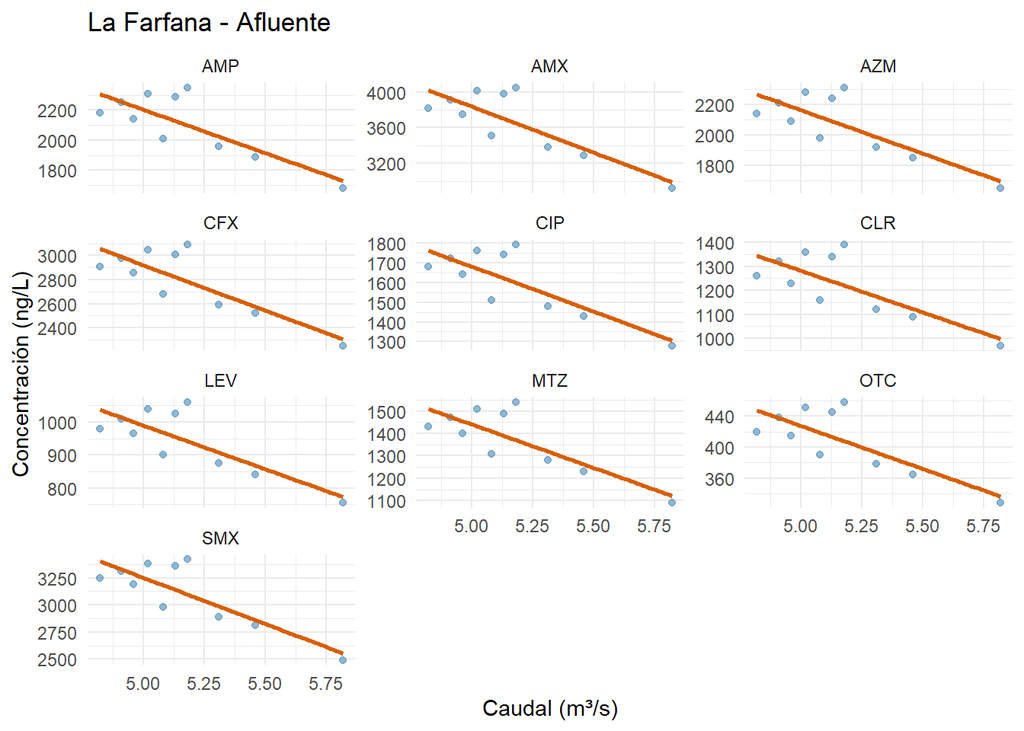

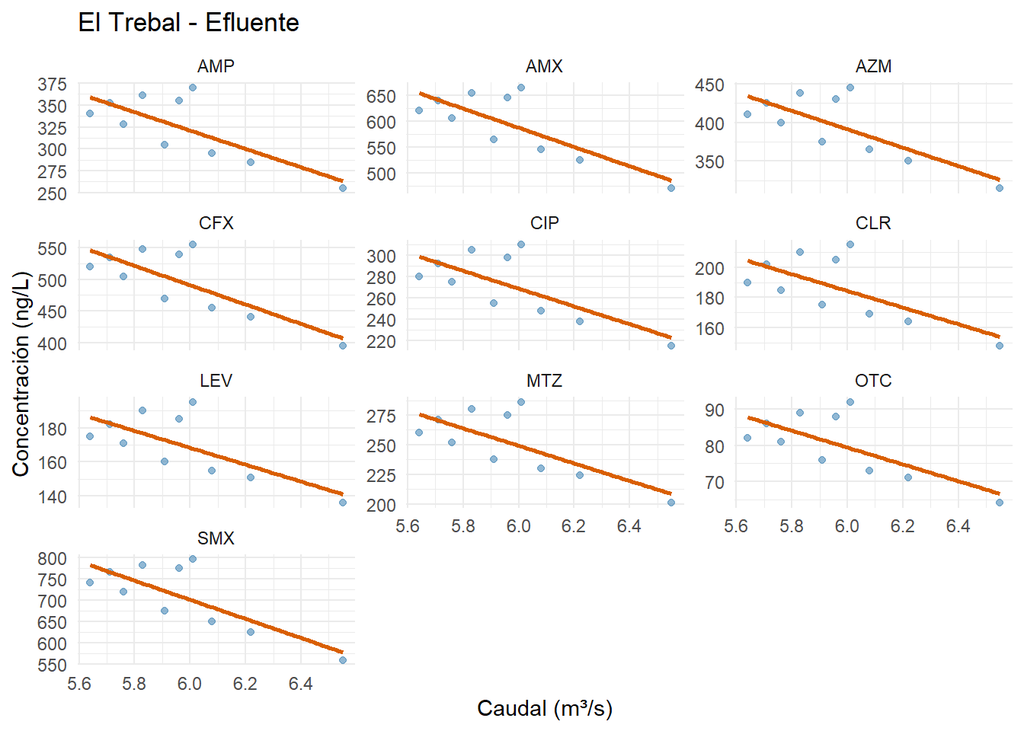

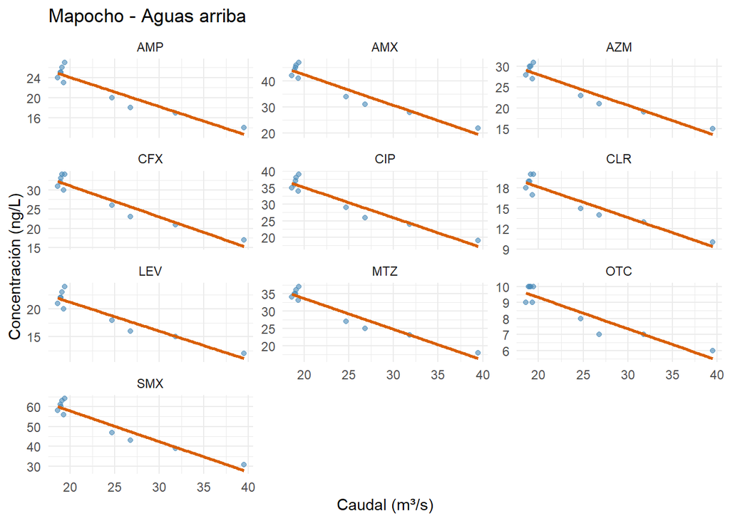

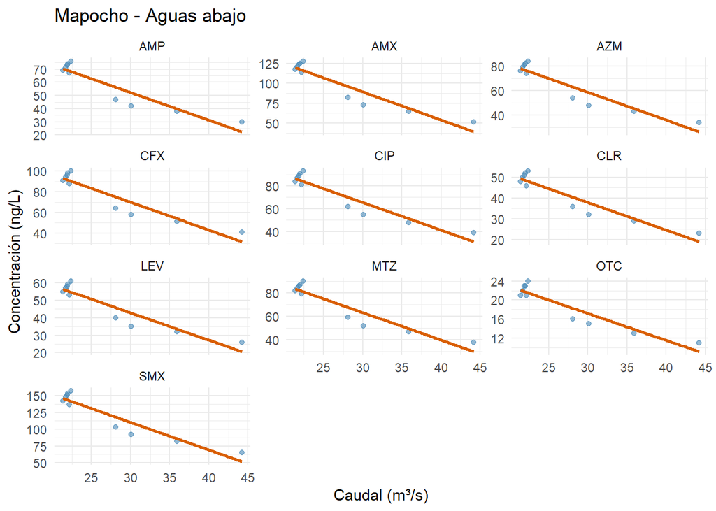

```r
#| label: fig-caudal-sitios
#| fig-cap: "Relación entre caudal y concentración por sitio."
#| fig-width: 11
#| fig-height: 7

for (sitio in unique(largo$Nombre_Sitio)) {

  datos_sitio <- largo |>
    filter(Nombre_Sitio == sitio)

  grafico <- ggplot(
    datos_sitio,
    aes(
      x = Caudal_m3_s,
      y = Concentracion
    )
  ) +
    geom_point(
      color = "#4789B8",
      alpha = 0.6
    ) +
    geom_smooth(
      method = "lm",
      se = FALSE,
      color = "#D95F02"
    ) +
    facet_wrap(
      ~ Antibiotico,
      scales = "free_y",
      ncol = 3
    ) +
    labs(
      title = sitio,
      x = "Caudal (m³/s)",
      y = "Concentración (ng/L)"
    ) +
    theme_minimal()

  print(grafico)
}
```

## Reproducibilidad

Instalar los paquetes R `readxl`, `dplyr`, `tidyr`, `ggplot2`, `broom`, `knitr` y `plotly`, y ejecutar **Render** en RStudio (o `quarto render informe_antibioticos_quarto.qmd`).